# Working with Text

ASI: Introduction to R

Author

Affiliation

Dr Stevie Pederson

Black Ochre Data Labs  
Telethon Kids Institute

Published

November 21, 2023

# Working With Text

## Section Setup

- Clear your `R` Environment
- Create a new R script `TextManipulation.R`
- Add `library(tidyverse)` to the top of the script and execute

## Working with Text

- Text manipulation is an essential part of most analyses
  - Tidying axis labels
  - Correcting errors
  - Extracting shorter sample ids from full names
  - Extracting treatment information from columns
- Regular Expressions form a key part of this
  - `regex` is *not* an `R` exclusive concept
  - Pattern matching technique used in `bash`, `python` etc
  - `R` syntax is slightly different but mostly compatible

# Text Manipulation Using `stringr`

## Character Vectors

- We can use `c()` to form a character vector
- All values must be quoted $\implies$ unquoted text represents an `R` object
  - `ggplot` allows unquoted column names
  - Columns $\approx$ R objects (vectors)
- The unquoted names in the tidyverse is a new idea
- Widely used but old-school `R` purists prefer not

. . .

```r
pets <- c("My dog", "Your cat", "No-one's rat")
pets
```

```
[1] "My dog"       "Your cat"     "No-one's rat"
```

```r
length(pets)
```

```
[1] 3
```

```r
typeof(pets)
```

```
[1] "character"
```

- We can extract values using square brackets `[]`

## Text Manipulation

- `stringr` is always loaded with the `tidyverse`
- Contains nearly all functions you can imagine for text manipulation

. . .

- Count the characters

```r
str_length(pets)
```

```
[1]  6  8 12
```

. . .

- Trim to a set length

```r
str_trunc(pets, width = 6)
```

```
[1] "My dog" "You..." "No-..."
```

## Text Manipulation

- Change the case of strings

```r
str_to_upper(pets)
```

```
[1] "MY DOG"       "YOUR CAT"     "NO-ONE'S RAT"
```

```r
str_to_lower(pets)
```

```
[1] "my dog"       "your cat"     "no-one's rat"
```

```r
str_to_title(pets)
```

```
[1] "My Dog"       "Your Cat"     "No-One's Rat"
```

. . .

- Sort vectors into alphabetic order

```r
str_sort(pets)
```

```
[1] "My dog"       "No-one's rat" "Your cat"
```

## Pattern Matching

```r
pets
```

```
[1] "My dog"       "Your cat"     "No-one's rat"
```

. . .

- We can search for single letters $\implies$ case-sensitive

```r
str_detect(pets, "y")
```

```
[1]  TRUE FALSE FALSE
```

. . .

- Or patterns

```r
str_detect(pets, "dog")
```

```
[1]  TRUE FALSE FALSE
```

. . .

- Alternatives can be set using `|` $\implies$ interpreted a `OR`

```r
str_detect(pets, "(dog|cat)")
```

```
[1]  TRUE  TRUE FALSE
```

## Pattern Matching

- Patterns can be ‘negated’ using `negate = TRUE`

```r
str_detect(pets, "(dog|cat)", negate = TRUE)
```

```
[1] FALSE FALSE  TRUE
```

. . .

- Or by using `!` to negate the logical values

```r
!str_detect(pets, "(dog|cat)")
```

```
[1] FALSE FALSE  TRUE
```

## Returning A Subset

- A subset of values which match a pattern can be returned

```r
str_subset(pets, "at")
```

```
[1] "Your cat"     "No-one's rat"
```

. . .

- We can also use `negate = TRUE` here

```r
str_subset(pets, "at", negate = TRUE)
```

```
[1] "My dog"
```

. . .

- The “long way” might also be useful

```r
pets[str_detect(pets, "dog")]
```

```
[1] "My dog"
```

## Extracting Text

- We can extract patterns from *within* each element

```r
str_extract(pets, "dog")
```

```
[1] "dog" NA    NA
```

. . .

- Note that `NA` is returned where no pattern is found
  - i.e. the pattern is *missing* from that string
  - `NA` is Not Available / Missing

. . .

- We can also use the `|` to represent `OR`

```r
str_extract(pets, "(dog|cat)")
```

```
[1] "dog" "cat" NA
```

## Extracting Text

- We can specify a range of values

```r
str_extract(pets, "[cr]at")
```

```
[1] NA    "cat" "rat"
```

. . .

- Larger ranges can be set
  - `"[A-Z]"` restricts the pattern to any *uppercase* letters
  - If multiple matches occur, *only the first match is returned*

```r
str_extract(pets, "[A-Z]")
```

```
[1] "M" "Y" "N"
```

. . .

- Select lower-case letters using `"[a-z]"`

```r
str_extract(pets, "[a-z]")
```

```
[1] "y" "o" "o"
```

## Extracting Text

- Patterns can be anchored to the end of a string using “$”

```r
str_extract(pets, "[a-z]$")
```

```
[1] "g" "t" "t"
```

. . .

- Patterns can be anchored to the start using “^”
  - Notice that no lower-case letters are at the start of our vector

```r
str_extract(pets, "^[a-z]")
```

```
[1] NA NA NA
```

. . .

- Using “^” **inside** the square brackets acts as “NOT”

```r
str_extract(pets, "[^A-Z]")
```

```
[1] "y" "o" "o"
```

## Extracting Text

- Patterns can be extended by adding a `+` symbol  
  $\implies$ Match one or more values
  - Will return the first match of *one or more lowercase letters*

```r
str_extract(pets, "[a-z]+")
```

```
[1] "y"   "our" "o"
```

. . .

- `[A-Za-z]` can be combined as `[:alpha:]`

```r
str_extract(pets, "[:alpha:]+")
```

```
[1] "My"   "Your" "No"
```

. . .

- What happened at each non-letter? *The match stopped*

## Removing Text

- We can remove patterns using `str_remove()`

```r
str_remove(pets, "o")
```

```
[1] "My dg"       "Yur cat"     "N-one's rat"
```

. . .

- This only removed the first match
  - `str_remove_all()` removes all matches

```r
str_remove_all(pets, "o")
```

```
[1] "My dg"      "Yur cat"    "N-ne's rat"
```

```r
str_remove_all(pets, "[A-Z]")
```

```
[1] "y dog"       "our cat"     "o-one's rat"
```

## Wildcards

- Regular Expressions use `"."` as a wildcard  
  $\implies$ `*` extends a match *zero* or more times (similar to `+`)

. . .

- The pattern `" ."` matches a space followed by anything

```r
str_remove_all(pets, " ")
```

```
[1] "Mydog"       "Yourcat"     "No-one'srat"
```

```r
str_remove_all(pets, " .")
```

```
[1] "Myog"       "Yourat"     "No-one'sat"
```

. . .

- A very common pattern is `".+"`
  - Means *match anything any number of times*

. . .

```r
str_remove_all(pets, " .+")
```

```
[1] "My"       "Your"     "No-one's"
```

. . .

- Often multiple ways to obtain your target

## Replacing Patterns

- `str_replace_all()` is the most powerful of the core functions
- Has arguments `string`, `pattern` and `replacement`
  - The pattern `"a"` will be replaced by `"o"`

```r
str_replace_all(pets, pattern = "a", replacement = "o")
```

```
[1] "My dog"       "Your cot"     "No-one's rot"
```

. . .

- Turn all lowercase letters into `a`

```r
str_replace_all(pets, "[a-z]", "a")
```

```
[1] "Ma aaa"       "Yaaa aaa"     "Na-aaa'a aaa"
```

## Replacing Patterns

- We can capture patterns and return however we wish
  - Patterns to capture are placed within a `"()"`
  - Captures are returned in order using `\\1`, `\\2`…

. . .

- The follow pattern captures the entire text string `"(.+)"`
  - Match anything, any number of times
  - Then return with exclamations added

```r
str_replace_all(pets, "(.+)", "\\1!!!")
```

```
[1] "My dog!!!"       "Your cat!!!"     "No-one's rat!!!"
```

## Replacing Patterns

- We can also capture multiple patterns
  - Can you understand the following?

```r
str_replace_all(pets, "(.+) (.)(.)(.)", "\\1 \\4\\3\\2")
```

```
[1] "My god"       "Your tac"     "No-one's tar"
```

## Other Useful Functions

- `paste()` is a key `base` function
  - Combines text from two vectors
  - `R` automatically recycles values when vector lengths don’t match

```r
paste(c("A", "B", "C"), 1:3)
```

```
[1] "A 1" "B 2" "C 3"
```

```r
paste(pets, "is great")
```

```
[1] "My dog is great"       "Your cat is great"     "No-one's rat is great"
```

## Other Useful Functions

- `paste()` uses `sep = " "` as the default separator
  - Can be any characters at all

```r
paste(pets, "Hmm...", sep = "? ")
```

```
[1] "My dog? Hmm..."       "Your cat? Hmm..."     "No-one's rat? Hmm..."
```

. . .

- `paste0()` is a shortcut for `paste(sep = "")`

```r
paste0(pets, "!!!")
```

```
[1] "My dog!!!"       "Your cat!!!"     "No-one's rat!!!"
```

## Some Challenges

1. Given a vector of Transcript IDs with versions, remove the version number?

```r
ids <- c("ENST00000376207.10", "ENST00000376199.7")
```

2. Add the ‘chr’ prefix to these chromosomes

```r
chr <- c(1:22, "X", "Y", "M")
```

3. Pull the chromosome out of these cytogenetic bands

```r
cyto <- c("Xp11.23", "11q2.3", "2p7.1")
```

4. Convert the following genes from human to mouse

```r
genes <- c("FOXP3", "IL2RA", "CTLA4")
```

5. Remove the suffix “.bam” from these filenames

```r
bams <- c("rna_bamboo1.bam", "rna_rice1.bam", "rna_wheat1.bam")
```

6. Load the `RealTimeData.xlsx` file as before. Extract the timepoint from the first column, ensuring that “h” is always lower case.

Most of these have multiple solutions

## Working With Strings

- Is an incredibly common and important part of working with R
- Extract sample IDs from file names
- Pull key information from columns
- Remove prefixes/suffixes
- Correct data entry errors in your spreadsheet
- Format for pretty plotting

# Factors

## Factors

- Categorical variables are called `factors`
- `forcats` is the `tidyverse` package
  - Genius name…
- `base` functions are still very commonly used and simple
  - `as.factor()` and `factor()`

. . .

- Character vectors are always quoted when printed
- Factors are never shown quoted

**Very easy to mix characters and factors up**

## Factors

```r
pigs <- read_csv("data/pigs.csv")
dose <- pigs$dose
dose
```

```
 [1] "Low"  "Low"  "Low"  "Low"  "Low"  "Low"  "Low"  "Low"  "Low"  "Low"
[11] "Med"  "Med"  "Med"  "Med"  "Med"  "Med"  "Med"  "Med"  "Med"  "Med"
[21] "High" "High" "High" "High" "High" "High" "High" "High" "High" "High"
[31] "Low"  "Low"  "Low"  "Low"  "Low"  "Low"  "Low"  "Low"  "Low"  "Low"
[41] "Med"  "Med"  "Med"  "Med"  "Med"  "Med"  "Med"  "Med"  "Med"  "Med"
[51] "High" "High" "High" "High" "High" "High" "High" "High" "High" "High"
```

- Notice that we have many repeated values
  - Very common for categorical variables
- `as.factor()` from `base` creates factors in alphanumeric order
  - Prints the category levels at the bottom

```r
dose_fct <- as.factor(dose)
dose_fct
```

```
 [1] Low  Low  Low  Low  Low  Low  Low  Low  Low  Low  Med  Med  Med  Med  Med
[16] Med  Med  Med  Med  Med  High High High High High High High High High High
[31] Low  Low  Low  Low  Low  Low  Low  Low  Low  Low  Med  Med  Med  Med  Med
[46] Med  Med  Med  Med  Med  High High High High High High High High High High
Levels: High Low Med
```

- This is how our first boxplots were produced

## Factors

- We can manually set the levels using `factor()`
  - Levels are passed *as a character vector*
  - Enables us to manually set the order

```r
dose_fct <- factor(dose, levels = c("Low", "Med", "High"))
dose_fct
```

```
 [1] Low  Low  Low  Low  Low  Low  Low  Low  Low  Low  Med  Med  Med  Med  Med
[16] Med  Med  Med  Med  Med  High High High High High High High High High High
[31] Low  Low  Low  Low  Low  Low  Low  Low  Low  Low  Med  Med  Med  Med  Med
[46] Med  Med  Med  Med  Med  High High High High High High High High High High
Levels: Low Med High
```

## Forcats

- `forcats` offers some new approaches
  - `fct` creates factors in order (as does `fct_inorder()`)

```r
fct(dose)
```

```
 [1] Low  Low  Low  Low  Low  Low  Low  Low  Low  Low  Med  Med  Med  Med  Med
[16] Med  Med  Med  Med  Med  High High High High High High High High High High
[31] Low  Low  Low  Low  Low  Low  Low  Low  Low  Low  Med  Med  Med  Med  Med
[46] Med  Med  Med  Med  Med  High High High High High High High High High High
Levels: Low Med High
```

```r
fct_inorder(dose)
```

```
 [1] Low  Low  Low  Low  Low  Low  Low  Low  Low  Low  Med  Med  Med  Med  Med
[16] Med  Med  Med  Med  Med  High High High High High High High High High High
[31] Low  Low  Low  Low  Low  Low  Low  Low  Low  Low  Med  Med  Med  Med  Med
[46] Med  Med  Med  Med  Med  High High High High High High High High High High
Levels: Low Med High
```

## Forcats

- Can reformat the category levels

```r
fct_relabel(dose_fct, .fun = str_to_lower)
```

```
 [1] low  low  low  low  low  low  low  low  low  low  med  med  med  med  med
[16] med  med  med  med  med  high high high high high high high high high high
[31] low  low  low  low  low  low  low  low  low  low  med  med  med  med  med
[46] med  med  med  med  med  high high high high high high high high high high
Levels: low med high
```

. . .

- Reverse the order

```r
fct_rev(dose_fct)
```

```
 [1] Low  Low  Low  Low  Low  Low  Low  Low  Low  Low  Med  Med  Med  Med  Med
[16] Med  Med  Med  Med  Med  High High High High High High High High High High
[31] Low  Low  Low  Low  Low  Low  Low  Low  Low  Low  Med  Med  Med  Med  Med
[46] Med  Med  Med  Med  Med  High High High High High High High High High High
Levels: High Med Low
```

## Our Previous Plot

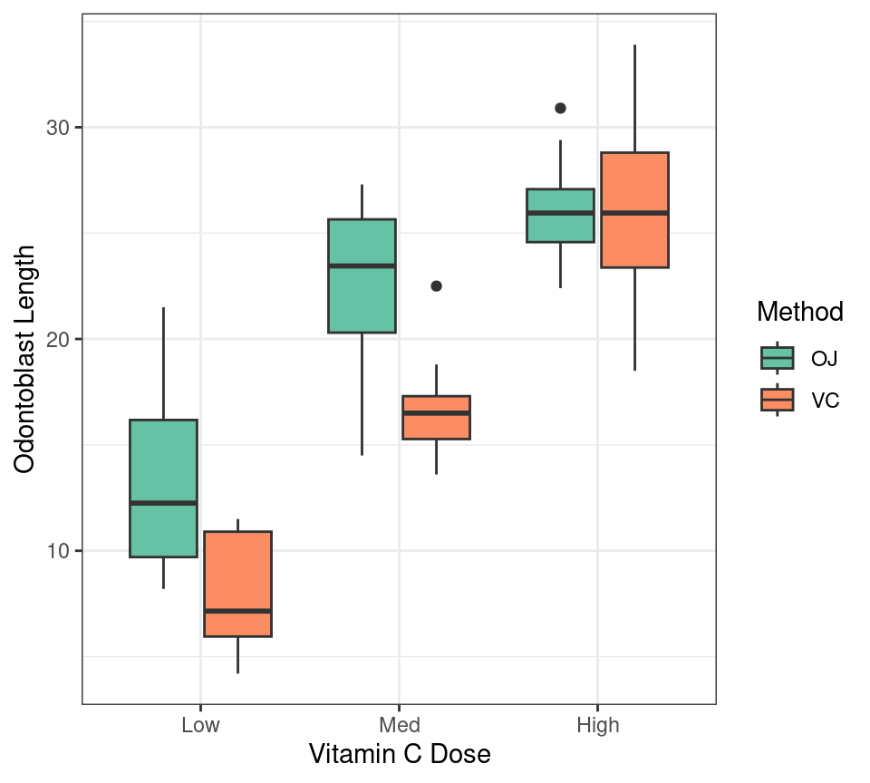

```r
## First change the original column
pigs$dose <- factor(
  pigs$dose, levels = c("Low", "Med", "High")
)
## Then make the plot
ggplot(
  pigs, aes(x = dose, y = len, fill = supp)
) +
  geom_boxplot() +
  scale_fill_brewer(palette = "Set2") +
  labs(
    x = "Vitamin C Dose",
    y = "Odontoblast Length",
    fill = "Method"
  ) +
  theme_bw()
```

## Factors

- All plotting functions automatically coerce strings to factors
- Performing manually gives far greater control
- Also useful for setting reference levels during statistical analysis